# Lab 7 - Unsupervised Clustering

## Name and ID: Roy Paz

```python
! mkdir ~/.kaggle
! cp kaggle.json ~/.kaggle/
! chmod 600 ~/.kaggle/kaggle.json
! kaggle datasets download d4rklucif3r/defaulter
! unzip /content/defaulter.zip
```

```
Downloading defaulter.zip to /content
  0% 0.00/150k [00:00<?, ?B/s]
100% 150k/150k [00:00<00:00, 73.3MB/s]
Archive:  /content/defaulter.zip
  inflating: credit_card_defaulter.csv
```

## About the data

This dataset is all about credit card defaulters. Our aim is to propose cluster deviation of the records into clusters using distance between records.

The dataset contains 5 Columns

- 1) ID - Id of customer
- 2) Default - Is the person a loan defaulter
- 3) Student - Is the person a student
- 4) Balance - Balance in his/her account
- 5) Income - His/Her income

## Task 1:

load the 'credit_card_defaulter.csv' file.

perform basic feature analysis (statistics, histograms)

use **label encoder** or **one hot encoder** to encode the binary variables

use **standard scaler** or **min max scaler** to scale the data

```python
import pandas as pd
data = pd.read_csv('/content/credit_card_defaulter.csv', index_col=0)
data
```

|  | default | student | balance | income |
| --- | --- | --- | --- | --- |
| 1 | No | No | 729.526495 | 44361.62507 |
| 2 | No | Yes | 817.180407 | 12106.13470 |
| 3 | No | No | 1073.549164 | 31767.13895 |
| 4 | No | No | 529.250605 | 35704.49394 |
| 5 | No | No | 785.655883 | 38463.49588 |
| ... | ... | ... | ... | ... |
| 9996 | No | No | 711.555020 | 52992.37891 |
| 9997 | No | No | 757.962918 | 19660.72177 |
| 9998 | No | No | 845.411989 | 58636.15698 |
| 9999 | No | No | 1569.009053 | 36669.11236 |
| 10000 | No | Yes | 200.922183 | 16862.95232 |

10000 rows × 4 columns

```python
# Implement here
from sklearn import preprocessing
from sklearn.preprocessing import MinMaxScaler

# encoding
le = preprocessing.LabelEncoder()
le.fit(data['default'])
data['default'] = le.transform(data['default'])
data['student'] = le.transform(data['student'])

#scaler
scaler = MinMaxScaler()
scaler.fit(data)
scaler.transform(data)
```

```
array([[0.        , 0.        , 0.2748447 , 0.59890492],
       [0.        , 1.        , 0.30786778, 0.15572704],
       [0.        , 0.        , 0.40445316, 0.42586159],
       ...,
       [0.        , 0.        , 0.31850386, 0.79503144],
       [0.        , 0.        , 0.59111468, 0.49321279],
       [0.        , 1.        , 0.07569622, 0.22108386]])
```

## Task 2:

Sample 20 records from the dataset. We will use those records only for the rest of this lab tasks.

calculate **Euclidean distance** matrix for those records.

Reminder : d(xi, xj) = sqrt((xi-xj)^2)

```python
# Implement here
from sklearn.metrics.pairwise import euclidean_distances

data20 = data.iloc[0:20,:]
euclidean = euclidean_distances(data20.to_numpy(), data20.to_numpy())
euclidean
```

```
array([[0.00000000e+00, 3.22556095e+04, 1.25991838e+04, 8.65944743e+03,
        5.89839626e+03, 3.68705564e+04, 1.94566353e+04, 2.67612908e+04,
        6.90659024e+03, 1.51039852e+04, 2.25023807e+04, 3.10969403e+04,
        1.61174556e+04, 6.44730424e+02, 2.05550278e+04, 8.12392622e+02,
        5.94859079e+03, 2.67258488e+04, 1.72062054e+04, 1.79007264e+04],
       [3.22556095e+04, 2.44140625e-04, 1.96626757e+04, 2.36001157e+04,
        2.63573801e+04, 4.61571232e+03, 1.27990946e+04, 5.49432323e+03,
        2.53647257e+04, 1.71885698e+04, 9.79907167e+03, 1.23043569e+03,
        1.61559799e+04, 3.28890944e+04, 1.17077764e+04, 3.29405576e+04,
        3.81679266e+04, 5.53798429e+03, 4.94610806e+04, 1.43611856e+04],
       [1.25991838e+04, 1.96626757e+04, 0.00000000e+00, 3.97479877e+03,
        6.70254270e+03, 2.42760686e+04, 6.86639375e+03, 1.41691637e+04,
        5.70206187e+03, 2.71328716e+03, 9.95412620e+03, 1.84991611e+04,
        3.61359693e+03, 1.32356513e+04, 7.95706254e+03, 1.32986003e+04,
        1.85292991e+04, 1.41411444e+04, 2.98047602e+04, 5.30255124e+03],
       [8.65944743e+03, 2.36001157e+04, 3.97479877e+03, 0.00000000e+00,
        2.77089072e+03, 2.82156355e+04, 1.08033304e+04, 1.81061988e+04,
        1.87376656e+03, 6.45097269e+03, 1.38435414e+04, 2.24465805e+04,
        7.45852472e+03, 9.29038510e+03, 1.19086344e+04, 9.34108082e+03,
        1.45704337e+04, 1.80679544e+04, 2.58616485e+04, 9.25717098e+03],
       [5.89839626e+03, 2.63573801e+04, 6.70254270e+03, 2.77089072e+03,
        0.00000000e+00, 3.09722269e+04, 1.35583279e+04, 2.08630573e+04,
        1.06343084e+03, 9.22175587e+03, 1.66110129e+04, 2.51986874e+04,
        1.02265265e+04, 6.53351011e+03, 1.46569770e+04, 6.59784621e+03,
        1.18279384e+04, 2.08285557e+04, 2.31045543e+04, 1.20028533e+04],
       [3.68705564e+04, 4.61571232e+03, 2.42760686e+04, 2.82156355e+04,
        3.09722269e+04, 0.00000000e+00, 1.74139221e+04, 1.01095013e+04,
        2.99779433e+04, 2.18031111e+04, 1.44088890e+04, 5.78483961e+03,
        2.07713540e+04, 3.75043021e+04, 1.63197613e+04, 3.75561954e+04,
        4.27836377e+04, 1.01525535e+04, 5.40762864e+04, 1.89738844e+04],
       [1.94566353e+04, 1.27990946e+04, 6.86639375e+03, 1.08033304e+04,
        1.35583279e+04, 1.74139221e+04, 0.00000000e+00, 7.30479473e+03,
        1.25677828e+04, 4.44732918e+03, 3.14444918e+03, 1.16433689e+04,
        3.39781518e+03, 2.00905204e+04, 1.13215302e+03, 2.01444062e+04,
        2.53735181e+04, 7.27479203e+03, 3.66624522e+04, 1.58253140e+03],
       [2.67612908e+04, 5.49432323e+03, 1.41691637e+04, 1.81061988e+04,
        2.08630573e+04, 1.01095013e+04, 7.30479473e+03, 0.00000000e+00,
        1.98712028e+04, 1.17027900e+04, 4.34651047e+03, 4.35142946e+03,
        1.06665717e+04, 2.73948487e+04, 6.21717429e+03, 2.74469343e+04,
        3.26748694e+04, 2.83434180e+02, 4.39668393e+04, 8.86880583e+03],
```

[output cut: 45 more lines]

```
       [2.67258488e+04, 5.53798429e+03, 1.41411444e+04, 1.80679544e+04,
        2.08285557e+04, 1.01525535e+04, 7.27479203e+03, 2.83434180e+02,
        1.98421057e+04, 1.16506783e+04, 4.26726755e+03, 4.42261642e+03,
        1.06191299e+04, 2.73581309e+04, 6.20132964e+03, 2.74069358e+04,
        3.26330371e+04, 0.00000000e+00, 4.39295862e+04, 8.84631553e+03],
       [1.72062054e+04, 4.94610806e+04, 2.98047602e+04, 2.58616485e+04,
        2.31045543e+04, 5.40762864e+04, 3.66624522e+04, 4.39668393e+04,
        2.41070321e+04, 3.22944940e+04, 3.96980073e+04, 4.83031309e+04,
        3.33153405e+04, 1.65719906e+04, 3.77611384e+04, 1.65248998e+04,
        1.13112366e+04, 4.39295862e+04, 0.00000000e+00, 3.51067597e+04],
       [1.79007264e+04, 1.43611856e+04, 5.30255124e+03, 9.25717098e+03,
        1.20028533e+04, 1.89738844e+04, 1.58253140e+03, 8.86880583e+03,
        1.10040957e+04, 3.01643234e+03, 4.72228368e+03, 1.31966661e+04,
        1.98237458e+03, 1.85363580e+04, 2.65451766e+03, 1.85953810e+04,
        2.38258599e+04, 8.84631553e+03, 3.51067597e+04, 0.00000000e+00]])
```

# Task 3:

For the same 20 records (from task 2), calculate **Manhattan distance** matrix

Reminder : d(xi, xj) = |xi-xj|

```python
# Implement here
from sklearn.metrics.pairwise import manhattan_distances

manhattan = manhattan_distances(data20.to_numpy(), data20.to_numpy())
manhattan
```

```
array([[    0.       , 32344.1442814, 12938.5087888,  8857.4070205,
         5954.2585777, 37061.1285333, 19552.3853253, 26841.3147391,
         7324.6271388, 15815.8832752, 23221.0784752, 31585.1201078,
        16602.4111112,   755.7149319, 20934.8929258,  1124.0819051,
         6633.2137752, 26928.0717611, 17448.070681 , 18262.5399198],
       [32344.1442814,     0.       , 19918.3730074, 23887.2890419,
        26389.8857037,  4716.9842519, 12808.4248039,  5502.8295423,
        25707.2720374, 17987.3139966, 10582.1187966,  1565.8308664,
        16726.6959326, 33099.8592133, 12000.8273444, 33468.2261865,
        38977.3580566,  5820.0451425, 49792.2149624, 14637.3890184],
       [12938.5087888, 19918.3730074,     0.       ,  4481.6535493,
         6984.2502111, 24430.5410115,  7109.9482035, 14432.5692697,
         5788.89903  ,  3565.419824 , 10970.615024 , 18646.611319 ,
         4351.94766  , 13694.2237207,  7996.384137 , 14062.5906939,
        19571.722564 , 14677.6083099, 30386.5794698,  5324.031131 ],
       [ 8857.4070205, 23887.2890419,  4481.6535493,     0.       ,
         3015.4072182, 28604.2732938, 11095.5300858, 18384.4594996,
         2395.8425993,  6958.4762547, 14363.6714547, 23128.2648683,
         7745.0040907,  9367.5536486, 12478.0376863,  9580.9371446,
        15090.0690147, 18070.6647406, 25904.9259205,  9805.6846803],
       [ 5954.2585777, 26389.8857037,  6984.2502111,  3015.4072182,
            0.       , 31106.8699556, 13598.1267476, 20887.0561614,
         1370.3685611,  9973.8834729, 17379.0786729, 25630.8615301,
        10760.4113089,  6709.9735096, 14980.6343481,  7078.3404828,
        12587.4723529, 21086.0719588, 23402.3292587, 12308.2813421],
       [37061.1285333,  4716.9842519, 24430.5410115, 28604.2732938,
        31106.8699556,     0.       , 17508.743208 , 10219.8137942,
        30219.4400415, 22704.2982485, 15299.1030485,  6077.9988705,
        21443.6801845, 37816.8434652, 16512.9953485, 38185.2104384,
        43694.3423085, 10537.0293944, 54509.1992143, 19149.5570225],
       [19552.3853253, 12808.4248039,  7109.9482035, 11095.5300858,
        13598.1267476, 17508.743208 ,     0.       ,  7322.6210662,
        12898.8472335,  5195.5550405,  3860.6668205, 12032.7347825,
         3934.9369765, 20308.1002572,  1382.5076005, 20676.4672304,
        26185.5991005,  7567.6601064, 37000.4560063,  1828.9642145],
       [26841.3147391,  5502.8295423, 14432.5692697, 18384.4594996,
        20887.0561614, 10219.8137942,  7322.6210662,     0.       ,
        20221.4682997, 12484.4844543,  5079.2892543,  4743.8053687,
        11223.8663903, 27597.029671 ,  6515.0236067, 27965.3966442,
        33474.5285143,   317.2156002, 44289.3854201,  9151.5852807],
```

[output cut: 45 more lines]

```
       [26928.0717611,  5820.0451425, 14677.6083099, 18070.6647406,
        21086.0719588, 10537.0293944,  7567.6601064,   317.2156002,
        20466.5073399, 12167.2688541,  4762.0736541,  5061.0209689,
        10906.6507901, 27438.2183892,  6760.0626469, 27648.181044 ,
        33157.3129141,     0.       , 43972.1698199,  9396.6243209],
       [17448.070681 , 49792.2149624, 30386.5794698, 25904.9259205,
        23402.3292587, 54509.1992143, 37000.4560063, 44289.3854201,
        24772.6978198, 32776.7746942, 40181.9698942, 49033.1907888,
        33563.3025302, 16692.3557491, 38382.9636068, 16723.3973841,
        11786.7306342, 43972.1698199,     0.       , 35710.6106008],
       [18262.5399198, 14637.3890184,  5324.031131 ,  9805.6846803,
        12308.2813421, 19149.5570225,  1828.9642145,  9151.5852807,
        11069.883019 ,  3905.709635 ,  5689.631035 , 13322.580188 ,
         2645.091571 , 19018.2548517,  2672.353006 , 19386.6218249,
        24895.753695 ,  9396.6243209, 35710.6106008,     0.       ]])
```

## Task 4:

Use scipy.cluster.hierarchy to plot dendrogram **for each** of the distance matrices. **explain the differences between them and why?**

Note: Your plots should look like this:

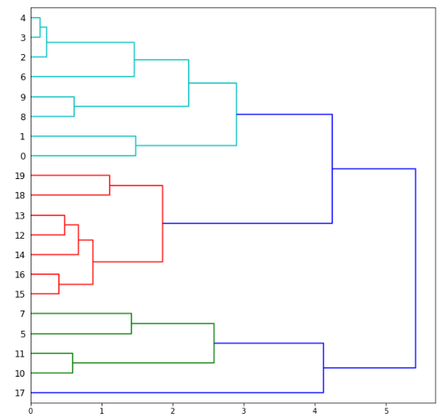

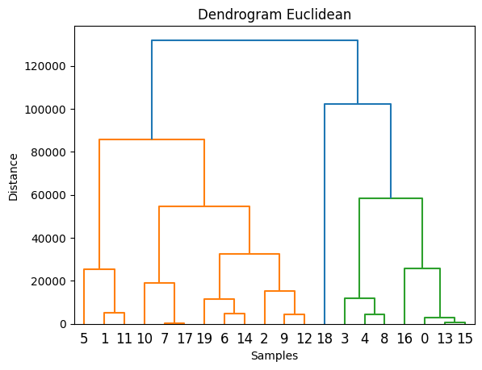

```python
# Implement here
import scipy.cluster.hierarchy as sch
import matplotlib.pyplot as plt


dist_matrix = sch.distance.pdist(euclidean)
linkage_matrix = sch.linkage(dist_matrix, method='complete')
dendrogram = sch.dendrogram(linkage_matrix)
plt.title('Dendrogram Euclidean')
plt.xlabel('Samples')
plt.ylabel('Distance')
plt.show()
```

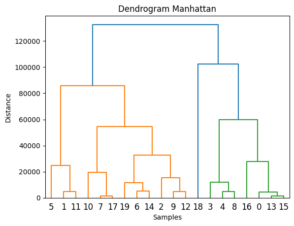

```python
# Implement here
dist_matrix = sch.distance.pdist(manhattan)
linkage_matrix = sch.linkage(dist_matrix, method='complete')
dendrogram = sch.dendrogram(linkage_matrix)
plt.title('Dendrogram Manhattan')
plt.xlabel('Samples')
plt.ylabel('Distance')
plt.show()
```

explain the differences between them and why? \ Answer: If we mesure the plots we can see that, the Manhattan dendogram shows bigger distances between the records. \ Due to the equation of Manhattan distance that counts the distance 'arround the blocks' compared to Euclidean distance equation that calculates the directed distance.

## Task 5:

Convert the notebook into html:

1. Download the notebook by clicking the File tab
2. Upload it to this environment
3. Run the command:

```python
%%shell
jupyter nbconvert --to html Lab7.ipynb
```